# Regression Tutorial

## Regression Tutorial: UCI Red Wine Quality Dataset

In this tutorial, simple linear regression will be modelled with the red wine quality dataset. In this dataset, various parameters describing wine such as the fixed acidity, pH, total sulfur dioxide, etc. will be used to rate wine quality from a scale of 0 to 10.

The dataset is availiable at UCI Machine Learning Repository (https://archive.ics.uci.edu/ml/datasets/Wine+Quality)

- Linear Regression
- Lasso, Ridge, and ElasticNet Regression
- Decision Tree Regression
- Random Forest Regression
- Support Vector Regression

```r
df = read.csv("/Users/tantaotao/Desktop/PythonDB/week12/winequality-red.csv", sep = ";")
head(df)
```

```
##   fixed.acidity volatile.acidity citric.acid residual.sugar chlorides
## 1           7.4             0.70        0.00            1.9     0.076
## 2           7.8             0.88        0.00            2.6     0.098
## 3           7.8             0.76        0.04            2.3     0.092
## 4          11.2             0.28        0.56            1.9     0.075
## 5           7.4             0.70        0.00            1.9     0.076
## 6           7.4             0.66        0.00            1.8     0.075
##   free.sulfur.dioxide total.sulfur.dioxide density   pH sulphates alcohol
## 1                  11                   34  0.9978 3.51      0.56     9.4
## 2                  25                   67  0.9968 3.20      0.68     9.8
## 3                  15                   54  0.9970 3.26      0.65     9.8
## 4                  17                   60  0.9980 3.16      0.58     9.8
## 5                  11                   34  0.9978 3.51      0.56     9.4
## 6                  13                   40  0.9978 3.51      0.56     9.4
##   quality
## 1       5
## 2       5
## 3       5
## 4       6
## 5       5
## 6       5
```

In this case, our target will be the quality of the wine. We will separate the target from the rest of the data, which will be scaled using the a z-scoring normalization.

The motivation of StandardScaler() is that it transforms the data such that its distribution will have a mean of 0 and standard deviation of 1. In other words, the transformed value of the dataframe is the (original value - mean) / standard deviation.

Additional information about feature scaling can be found in the following link. (http://sebastianraschka.com/Articles/2014_about_feature_scaling.html#standardization-and-min-max-scaling)

```r
df_data = scale(df[,1:11])
scaled_df = data.frame(cbind("quality" = df$quality, df_data))

head(scaled_df)
```

```
##   quality fixed.acidity volatile.acidity citric.acid residual.sugar   chlorides
## 1       5    -0.5281944        0.9615758   -1.391037    -0.45307667 -0.24363047
## 2       5    -0.2984541        1.9668271   -1.391037     0.04340257  0.22380518
## 3       5    -0.2984541        1.2966596   -1.185699    -0.16937425  0.09632273
## 4       6     1.6543385       -1.3840105    1.483689    -0.45307667 -0.26487754
## 5       5    -0.5281944        0.9615758   -1.391037    -0.45307667 -0.24363047
## 6       5    -0.5281944        0.7381867   -1.391037    -0.52400227 -0.26487754
##   free.sulfur.dioxide total.sulfur.dioxide    density         pH   sulphates
## 1         -0.46604672           -0.3790141 0.55809987  1.2882399 -0.57902538
## 2          0.87236532            0.6241680 0.02825193 -0.7197081  0.12891007
## 3         -0.08364328            0.2289750 0.13422152 -0.3310730 -0.04807379
## 4          0.10755844            0.4113718 0.66406945 -0.9787982 -0.46103614
## 5         -0.46604672           -0.3790141 0.55809987  1.2882399 -0.57902538
## 6         -0.27484500           -0.1966174 0.55809987  1.2882399 -0.57902538
##      alcohol
## 1 -0.9599458
## 2 -0.5845942
## 3 -0.5845942
## 4 -0.5845942
## 5 -0.9599458
## 6 -0.9599458
```

Next, the training and testing sets are created

```r
train_idx = sample(row.names(scaled_df), size = 0.7*nrow(scaled_df))
test_idx = setdiff(row.names(scaled_df), train_idx)

train_set = scaled_df[train_idx,]
test_set = scaled_df[test_idx,]
```

## Linear Regression

Linear Regression is calculated by minimize **residual sum of squares**.
$$RSS = \sum_{i = 1}^{n}(y_i - \beta_0 - \sum_{j=1}^{p} \beta_jx_{ij})^2$$
You can find a set of $\beta_j$, so that $RSS$ reach its minimum value. In math language, itâs:
$$\underset{\beta_0, \beta_j} {\arg \min} \Bigg\{RSS\Bigg\}$$

A heatmap may be helpful visual tool in determining which two attributes have the highest correlation to consider before building a model. A possible usage of the heatmap is to threshold out attributes that do not have high correlation pairs. For example, the pair (fixed acidity, density) have a correlation rho of 0.67 which is much higher than the (volatile acidity, residual sugar) pair.

This article (https://medium.com/datadriveninvestor/regression-from-scratch-wine-quality-prediction-d61195cb91c8) provides a step by step walk through on using feature selection based on a threshold for linear regression.

Here, we will show some metrics such as the MSE and MAE without thresholding features.

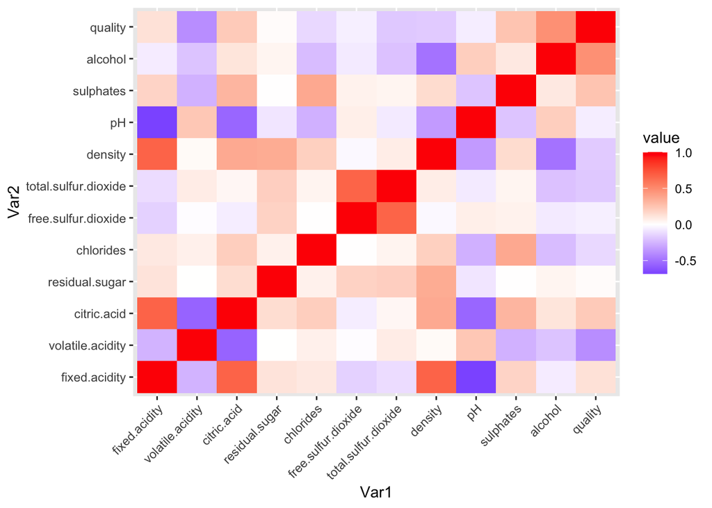

```r
library(reshape2)
library(ggplot2)

correlation_mat = cor(df)
melted_correlation_mat <- melt(correlation_mat)


ggplot(data = melted_correlation_mat, aes(x=Var1, y=Var2, fill=value)) +
  geom_tile() +
  scale_fill_gradient2(low = "blue", high = "red", mid = "white") +
  theme(axis.text.x = element_text(angle = 45, vjust = 1, hjust = 1))
```

```r
# fit the linear model
lin_reg = lm(train_set, formula = quality ~ .)
summary(lin_reg)
```

```
##
## Call:
## lm(formula = quality ~ ., data = train_set)
##
## Residuals:
##      Min       1Q   Median       3Q      Max
## -2.70311 -0.36326 -0.03491  0.44243  1.97176
##
## Coefficients:
##                      Estimate Std. Error t value Pr(>|t|)
## (Intercept)           5.65007    0.01953 289.332  < 2e-16 ***
## fixed.acidity         0.11352    0.05687   1.996  0.04618 *
## volatile.acidity     -0.19536    0.02644  -7.389 2.90e-13 ***
## citric.acid          -0.07300    0.03568  -2.046  0.04098 *
## residual.sugar        0.04126    0.02500   1.650  0.09918 .
## chlorides            -0.06725    0.02393  -2.810  0.00504 **
## free.sulfur.dioxide   0.02283    0.02723   0.839  0.40192
## total.sulfur.dioxide -0.08631    0.02903  -2.973  0.00301 **
## density              -0.06976    0.05069  -1.376  0.16908
## pH                   -0.06246    0.03644  -1.714  0.08675 .
## sulphates             0.15865    0.02462   6.445 1.73e-10 ***
## alcohol               0.30237    0.03454   8.754  < 2e-16 ***
## ---
## Signif. codes:  0 '***' 0.001 '**' 0.01 '*' 0.05 '.' 0.1 ' ' 1
##
## Residual standard error: 0.6525 on 1107 degrees of freedom
## Multiple R-squared:  0.3705, Adjusted R-squared:  0.3643
## F-statistic: 59.24 on 11 and 1107 DF,  p-value: < 2.2e-16
```

```r
# predict the outcome
y_hat =  predict(lin_reg, test_set)
df2 = as.data.frame(cbind("Actual_Quality" = test_set$quality, "Predicted_Quality"  = y_hat))
head(df2)
```

```
##    Actual_Quality Predicted_Quality
## 1               5          5.022047
## 3               5          5.241213
## 4               6          5.730920
## 7               5          5.128741
## 8               7          5.360987
## 17              7          5.795866
```

Below is a visual of the predictions and the actual qualities for comparision.

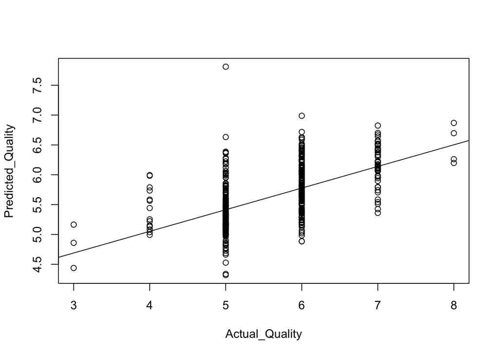

```r
plot(Predicted_Quality ~ Actual_Quality, data = df2)
abline(lm(Predicted_Quality ~ Actual_Quality, data = df2))
```

#### Metrics to evaluate a regression model

- $R^2$ coefficient of determination
- $MSE$ mean squared error
- $MAE$ mean absolute error

```r
# R^2 is essentially square of correlation
cor(df2$Actual_Quality, df2$Predicted_Quality)^2
```

```
## [1] 0.3251061
```

```r
# mean square error
mean((df2$Predicted_Quality - df2$Actual_Quality)^2)
```

```
## [1] 0.4141791
```

```r
# mean absolute error
mean(abs(df2$Predicted_Quality - df2$Actual_Quality))
```

```
## [1] 0.4955648
```

## Ridge Regression

Ridge Regression is calculated by minimize:
$$RSS_{ridge} = \sum_{i = 1}^{n}(y_i - \beta_0 - \sum_{j=1}^{p} \beta_jx_{ij})^2 + \lambda\sum_{j = 1}^{p} \beta_{j}^{2}$$
Notice an additional term has been added $\lambda\sum_{j = 1}^{p} \beta_{j}^{2}$. This is called $l_2$ penalization. Therefore, the final set of $\beta_j$ tend to be smaller than the $\beta_j$ determined by linear regression.

If we set $\lambda = 0$, Ridge regression is equivalent to linear regression.

If you want to build ridge regression, set alpha = 0.

```r
# install.packages("glmnet")
library(glmnet)
X_train = train_set[,2:ncol(train_set)]
y_train = train_set$quality
X_test = test_set[,2:ncol(train_set)]
y_test = test_set$quality

# set lambda = 0
ridge_model_lambda_0 = glmnet(X_train, y_train, alpha = 0, lambda = 0)
ridge_lambda_0_hat = predict(ridge_model_lambda_0, as.matrix(X_test))


# set lambda = 1
ridge_model_lambda_1 = glmnet(X_train, y_train, alpha = 0, lambda = 1)
ridge_lambda_1_hat = predict(ridge_model_lambda_1, as.matrix(X_test))

# prediction
df3 = as.data.frame(cbind(y_hat,ridge_lambda_0_hat, ridge_lambda_1_hat ))
colnames(df3) <- c("y hat", "ridge_lambda_0_hat", "ridge_lambda_1_hat")
head(df3)
```

```
##       y hat ridge_lambda_0_hat ridge_lambda_1_hat
## 1  5.022047           5.022046           5.263644
## 3  5.241213           5.240648           5.358941
## 4  5.730920           5.732035           5.768172
## 7  5.128741           5.128872           5.328102
## 8  5.360987           5.361703           5.453506
## 17 5.795866           5.795609           5.813151
```

### Check the coefficient

Notice the coefficient of linear model is the same as the coefficient of ridge regression (lambda = 0). The magnitude of coefficient of ridge regression (lambda = 1) tend to be smaller.

```r
df_coef_ridge = data.frame( as.matrix(cbind(coef(lin_reg), coef.glmnet(ridge_model_lambda_0), coef.glmnet(ridge_model_lambda_1))))
colnames(df_coef_ridge) = c("linear regression", "ridge lambda 0", "ridge lambda 1")
df_coef_ridge
```

```
##                      linear regression ridge lambda 0 ridge lambda 1
## (Intercept)                 5.65007025     5.65006869    5.655190168
## fixed.acidity               0.11351787     0.11532380    0.037899881
## volatile.acidity           -0.19536415    -0.19535562   -0.099449574
## citric.acid                -0.07300082    -0.07304821    0.042172747
## residual.sugar              0.04126132     0.04176115    0.011925869
## chlorides                  -0.06725378    -0.06704774   -0.042051324
## free.sulfur.dioxide         0.02282877     0.02268179   -0.002240903
## total.sulfur.dioxide       -0.08630969    -0.08610661   -0.048282744
## density                    -0.06975816    -0.07125300   -0.050908774
## pH                         -0.06246178    -0.06144642   -0.020773244
## sulphates                   0.15864604     0.15874177    0.079906937
## alcohol                     0.30237069     0.30159226    0.145820408
```

### Model evaluation

```r
y_fit_ridge = predict(ridge_model_lambda_1, as.matrix(X_train))
y_predict_ridge = predict(ridge_model_lambda_1, as.matrix(X_test))

(R2_train_ridge = as.numeric(cor(y_train, y_fit_ridge)^2))
```

```
## [1] 0.3564008
```

```r
(R2_test_ridge = as.numeric(cor(y_test, y_predict_ridge)^2))
```

```
## [1] 0.3209842
```

```r
(mse_ridge = as.numeric(mean((y_predict_ridge- y_test)^2)))
```

```
## [1] 0.4430921
```

## Lasso Regression

Lasso Regression is calculated by minimize:
$$RSS_{lasso} = \sum_{i = 1}^{n}(y_i - \beta_0 - \sum_{j=1}^{p} \beta_jx_{ij})^2 + \lambda\sum_{j = 1}^{p} |\beta_{j}|$$
Notice an additional term has been added $\lambda\sum_{j = 1}^{p} |\beta_{j}|$. The only difference between lasso and ridge is $\beta_{j}^2$ and $|\beta_{j}|$. This is called $l_1$ penalization.

If we set $\lambda = 0$, Lasso regression is equivalent to linear regression.

If you want to build lasso regression, set alpha = 1.

```r
# set lambda = 0
lasso_model_lambda_0 = glmnet(X_train, y_train, alpha = 1, lambda = 0)
lasso_lambda_0_hat = predict(lasso_model_lambda_0, as.matrix(X_test))


# set lambda = 0.1
lasso_model_lambda_0.1 = glmnet(X_train, y_train, alpha = 1, lambda = 0.1)
lasso_lambda_0.1_hat = predict(lasso_model_lambda_0.1, as.matrix(X_test))

# prediction
df4 = as.data.frame(cbind(y_hat,lasso_lambda_0_hat, lasso_lambda_0.1_hat ))
colnames(df4) <- c("y hat", "lasso_lambda_0_hat", "lasso_lambda_0.1_hat")
head(df4)
```

```
##       y hat lasso_lambda_0_hat lasso_lambda_0.1_hat
## 1  5.022047           5.022046             5.231447
## 3  5.241213           5.240648             5.302813
## 4  5.730920           5.732035             5.688560
## 7  5.128741           5.128872             5.288982
## 8  5.360987           5.361703             5.396325
## 17 5.795866           5.795609             5.905266
```

### Check the coefficient

Notice the coefficient of linear model is the same as the coefficient of lasso regression (lambda = 0). When we set lambda = 0.1, some coefficients will become 0s.

In fact, this is a major difference between lasso and ridge regression. In ridge regression, the coefficients might be shrinked, but the algorithm wonât force them to be 0. However, in lasso regression, some coefficients are forced to be 0.

```r
df_coef_lasso = data.frame( as.matrix(cbind(coef(lin_reg), coef.glmnet(lasso_model_lambda_0), coef.glmnet(lasso_model_lambda_0.1))))
colnames(df_coef_lasso) = c("linear regression", "lasso lambda 0", "lasso lambda 0.1")
df_coef_lasso
```

```
##                      linear regression lasso lambda 0 lasso lambda 0.1
## (Intercept)                 5.65007025     5.65006869       5.65305444
## fixed.acidity               0.11351787     0.11532380       0.00000000
## volatile.acidity           -0.19536415    -0.19535562      -0.15087891
## citric.acid                -0.07300082    -0.07304821       0.00000000
## residual.sugar              0.04126132     0.04176115       0.00000000
## chlorides                  -0.06725378    -0.06704774       0.00000000
## free.sulfur.dioxide         0.02282877     0.02268179       0.00000000
## total.sulfur.dioxide       -0.08630969    -0.08610661       0.00000000
## density                    -0.06975816    -0.07125300       0.00000000
## pH                         -0.06246178    -0.06144642       0.00000000
## sulphates                   0.15864604     0.15874177       0.04530509
## alcohol                     0.30237069     0.30159226       0.26073635
```

### Model evaluation

```r
y_fit_lasso = predict(lasso_model_lambda_0.1, as.matrix(X_train))
y_predict_lasso = predict(lasso_model_lambda_0.1, as.matrix(X_test))

(R2_train_lasso = as.numeric(cor(y_train, y_fit_lasso)^2))
```

```
## [1] 0.3362535
```

```r
(R2_test_lasso = as.numeric(cor(y_test, y_predict_lasso)^2))
```

```
## [1] 0.31273
```

```r
(mse_lasso = as.numeric(mean((y_predict_lasso- y_test)^2)))
```

```
## [1] 0.4310789
```

## Elastic Net Regression

Elastic Net Regression is the combination of ridge and lasso regression
$$RSS_{elastic} = \frac{ \sum_{i = 1}^{n}(y_i - \beta_0 - \sum_{j=1}^{p} \beta_jx_{ij})^2}{2n} + \lambda(\frac {1- \alpha}{2}\sum_{j = 1}^{p} \beta_{j}^{2} + \alpha\sum_{j = 1}^{p} |\beta_{j}|)$$
Notice an additional term has been added $\lambda(\frac {1- \alpha}{2}\sum_{j = 1}^{p} \beta_{j}^{2} + \alpha\sum_{j = 1}^{p} |\beta_{j}|)$. It is a combination of ridge and lasso regression.

If you want to build elastic net regression, set alpha = anything between 0 and 1

```r
# set alpha = 0.1
elastic_model_alpha_0.1 = glmnet(X_train, y_train, alpha = 0.1, lambda = 1)
elastic_alpha_0.1_hat = predict(elastic_model_alpha_0.1, as.matrix(X_test))

# prediction
df5 = as.data.frame(cbind(y_hat,elastic_alpha_0.1_hat))
colnames(df5) <- c("y hat", "elastic_alpha_0.1_hat")

head(df5)
```

```
##       y hat elastic_alpha_0.1_hat
## 1  5.022047              5.412876
## 3  5.241213              5.451870
## 4  5.730920              5.698738
## 7  5.128741              5.436876
## 8  5.360987              5.493026
## 17 5.795866              5.810529
```

### Check the coefficient

```r
df_coef_elastic = data.frame(as.matrix(cbind(coef(lin_reg), coef.glmnet(elastic_model_alpha_0.1))))
colnames(df_coef_elastic) = c("linear regression", "elastic alpha 0.1")
df_coef_elastic
```

```
##                      linear regression elastic alpha 0.1
## (Intercept)                 5.65007025       5.656984432
## fixed.acidity               0.11351787       0.000000000
## volatile.acidity           -0.19536415      -0.082482387
## citric.acid                -0.07300082       0.015727369
## residual.sugar              0.04126132       0.000000000
## chlorides                  -0.06725378       0.000000000
## free.sulfur.dioxide         0.02282877       0.000000000
## total.sulfur.dioxide       -0.08630969      -0.007476218
## density                    -0.06975816       0.000000000
## pH                         -0.06246178       0.000000000
## sulphates                   0.15864604       0.035980375
## alcohol                     0.30237069       0.130130132
```

### Model evaluation

```r
y_fit_elastic = predict(elastic_model_alpha_0.1, as.matrix(X_train))
y_predict_elastic = predict(elastic_model_alpha_0.1, as.matrix(X_test))

(R2_train_elastic = as.numeric(cor(y_train, y_fit_elastic)^2))
```

```
## [1] 0.3429162
```

```r
(R2_test_elastic = as.numeric(cor(y_test, y_predict_elastic)^2))
```

```
## [1] 0.316849
```

```r
(mse_elastic = as.numeric(mean((y_predict_elastic- y_test)^2)))
```

```
## [1] 0.4848987
```

## Decision Tree regression

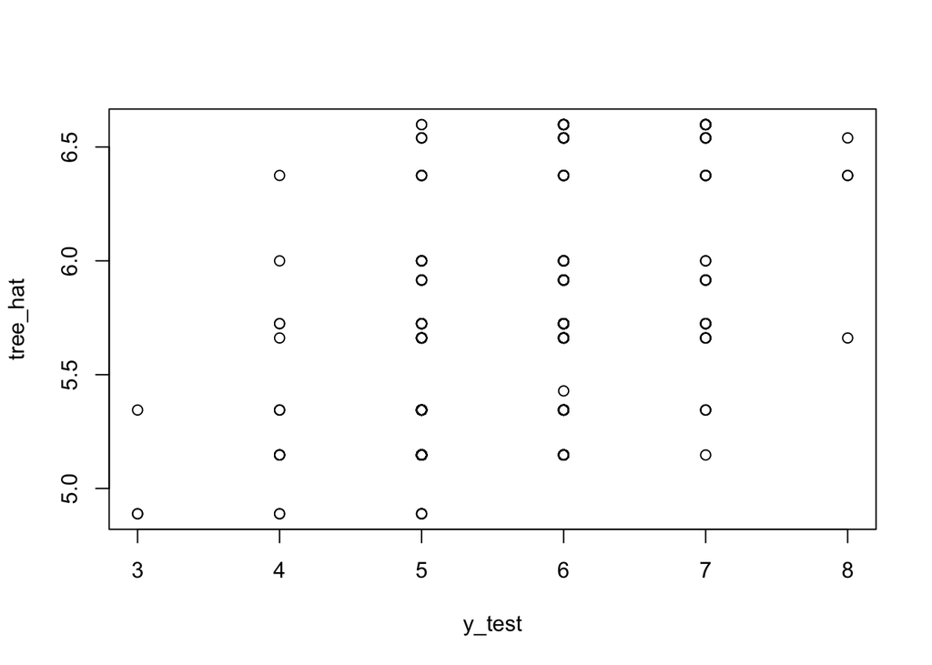

```r
# install.package("rpart)
library(rpart)
tree_reg = rpart(quality ~.,train_set)
tree_hat = predict(tree_reg, test_set)

plot(y_test, tree_hat)
```

## Random forest regression

```r
library(randomForest)
```

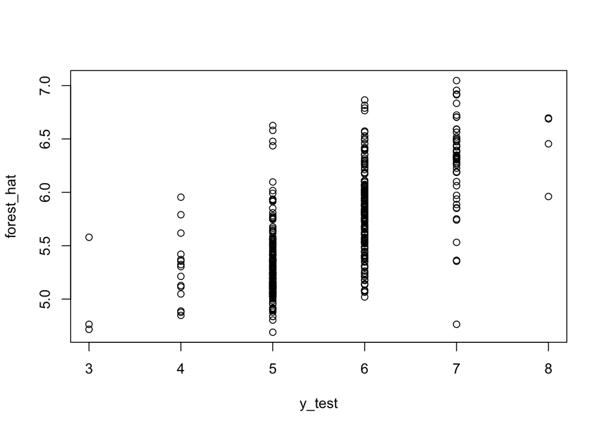

```r
forest_reg <- randomForest(quality ~.,train_set, importance = TRUE)
forest_hat = predict(forest_reg, test_set)
plot(y_test, forest_hat)
```

## SVM regression

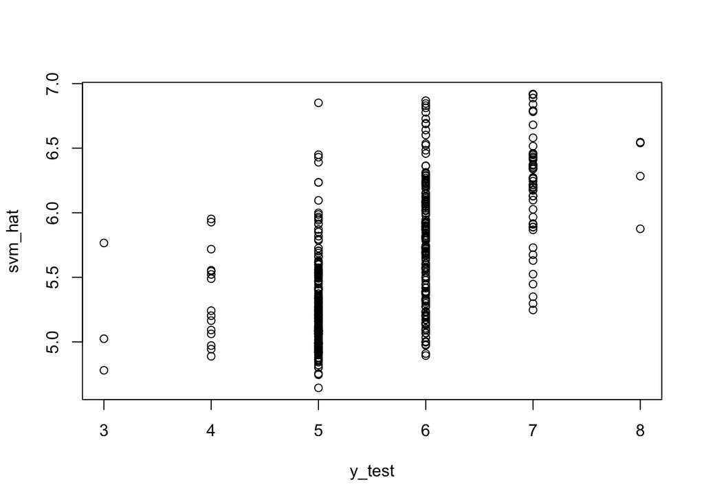

```r
library(e1071)
svm_reg = svm(quality ~.,train_set)
svm_hat = predict(svm_reg, test_set)
plot(y_test, svm_hat)
```